# From Gaps to Gains

Practical Applications for Teaching and Learning

Author

Michael – AI Facilitator

Published

January 1, 2025

## Companion Website

[figure not shown]

https://michaelborck.education/ai

## Today’s Journey

- **From Gaps to Gains** — setting the scene
- **Talk Buddy** — student practice with feedback
- **Insight Lens** — turning surveys into action
- **Quick Win** — FAQ → interactive quiz
- **Discussion & Concerns** — practical realities
- **Closing Reflection** — where do we go from here?

## From Gaps to Gains

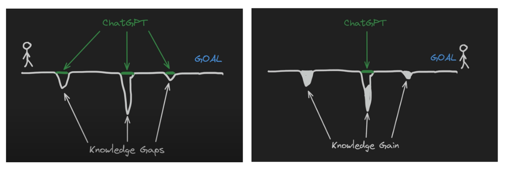

Gaps-to-Gains: Start -> End

**Start → End**  
- Students begin with gaps in knowledge  
- Our goal: help them transform gaps into genuine gains

*“So the question is: which story do we want to write in our classrooms?”*

## Talk Buddy — Conversation Practice

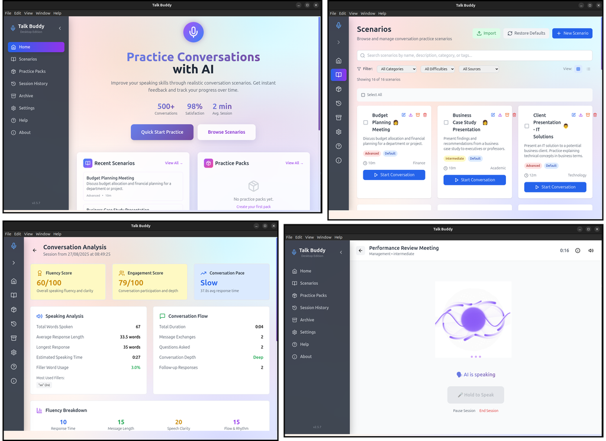

Talk Buddy

**Real Impact**

*“I practiced breaking bad news 10 times before placement. I felt prepared instead of terrified.”*

**Students:**  
- Practice professional conversations  
- Role-play difficult scenarios  
- Get instant feedback  
- Build confidence safely

**Lecturers:**  
- Create custom scenarios  
- Track common struggles  
- Provide targeted support  
- **Value:** Fail safely, learn, try again — no real-world consequences.

## Insight Lens — Your Feedback, Actionable

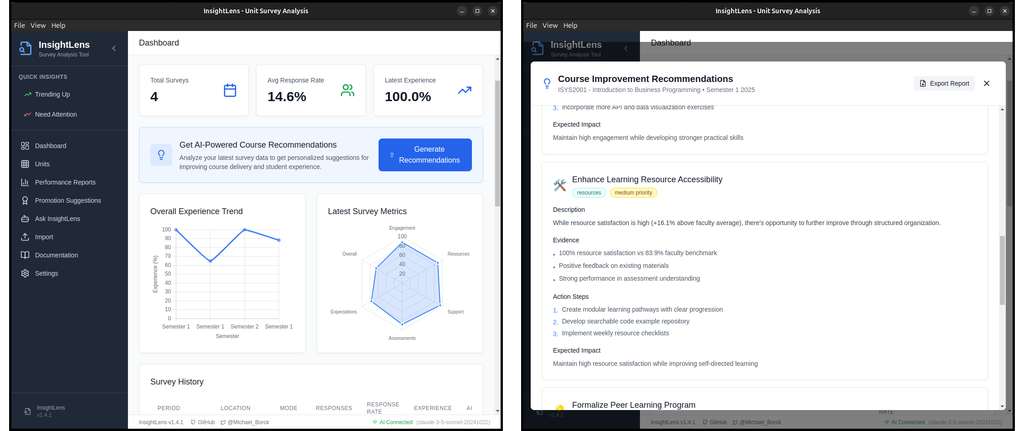

Insight Lens

**You upload:**  
- Student evaluations  
- Unit surveys  
- Mid-semester reviews

**Insight Lens finds:**  
- Common themes  
- Hidden patterns  
- Specific improvements

**Value:** Your expertise + data insights = better outcomes.

## Quick Win: Static → Interactive

**In 2 minutes:**  
1. Take an FAQ or worksheet  
2. Ask AI to make a interactive web page 3. Upload to Blackboard  
4. Students interact, save locally

*“No programming required — copy template, swap questions, done.”*

**Privacy First**

Runs in the browser. No logins. No data leaves the device.

## Common Concerns — Quick Answers

- **Plagiarism?** → Use AI as *editor* + require transparency
- **Lazy students?** → Design critique & reflection tasks
- **Replace teachers?** → No — AI handles routine, we do relationships
- **Data privacy?** → Use safe tools, no sensitive data in consumer AI

## Beyond Today: Other Tools in the Toolkit

- **CloudCore** – Scenario-based teaching platform
- **FeedForward** – Structured learning from feedback
- **Curriculum Curator** – AI-assisted course design
- **Study Buddy** – Offline AI tutor
- **TechNova-Sim** – Cybersecurity simulation
- **Critique Quest** – AI-powered case studies

Explore more: michaelborck.education

## Beyond Teaching: AI in Research

AI can also support research practice:

- **Audio transcription & thematic analysis** (Otter-style tools)
- **Literature review assistance** (search, summarise, compare)
- **Data handling & visualisation** (survey analysis, charting)
- **Drafting & editing support** (grants, papers, reviews)

Should the AI Facilitator role extend to **research support**?  
Add your view in the poll.

## Shaping Our Support

[figure not shown]

Poll open for the next few days — your input will shape how this role develops.

- Guidance on **safe use & policy**
- **Practical demos** & workshops
- Help with **curriculum integration**
- **Tools & resource** curation
- **One-to-one support** for teaching/assessment
- Research support (e.g. transcription, analysis, writing)
- Other (open text)

## Closing Reflection

AI isn’t about replacing educators —  
it’s about amplifying teaching and learning.

**So the real question is:**  
How do *we* take our students from gaps… to gains?

## Discussion & Next Steps

### What feels most relevant for your teaching?

- Try the **FAQ → quiz** activity
- Experiment with **Talk Buddy** or **Insight Lens**
- Explore more at michaelborck.education